# Practica 3: Regresión múltiple, control estadístico y parcialización

Estadistica Multivariada - Sociología FACSO Universidad de Chile

Juan Carlos Castillo & Alejandro Plaza

# 1 Introducción

En esta práctica nos enfocaremos en la comprensión del control estadístico a partir de la visualización de datos y la regresión parcial. Vamos a realizar dos ejercicios, el primero con los datos de la sesión correspondiene, y el segundo replicando el ejemplo de Darlington & Hayes

# 2 Ejemplo 1: ingreso, educación y experiencia.

Este ejericio corresponde al que se detalla en la sesión 6 [ver aquí](https://juancarloscastillo.github.io/metsoc-facsouchile/sesiones.html)

## 2.1 Librerías y datos

```r
pacman::p_load(dplyr,
               corrplot,
               ggplot2,
               texreg,
               stargazer)

datos=read.csv("https://juancarloscastillo.github.io/metsoc-facsouchile/documents/presentaciones/6regmul2/ingedexp.csv", sep="")
```

Ver datos

```r
stargazer(datos, type = "text", digits=0)
```

```
##
## =================================================
## Statistic   N   Mean   St. Dev.   Min      Max
## -------------------------------------------------
## ID          10    6       3        1       10
## ingreso     10 495,000 323,565  100,000 1,000,000
## educacion   10    4       2        1        6
## experiencia 10    2       1        1        3
## -------------------------------------------------
```

## 2.2 Correlaciones y scatters

```r
cormat=datos %>% select(ingreso,educacion,experiencia) %>% cor()
round(cormat, digits=2)
```

```
##             ingreso educacion experiencia
## ingreso        1.00      0.77        0.44
## educacion      0.77      1.00        0.27
## experiencia    0.44      0.27        1.00
```

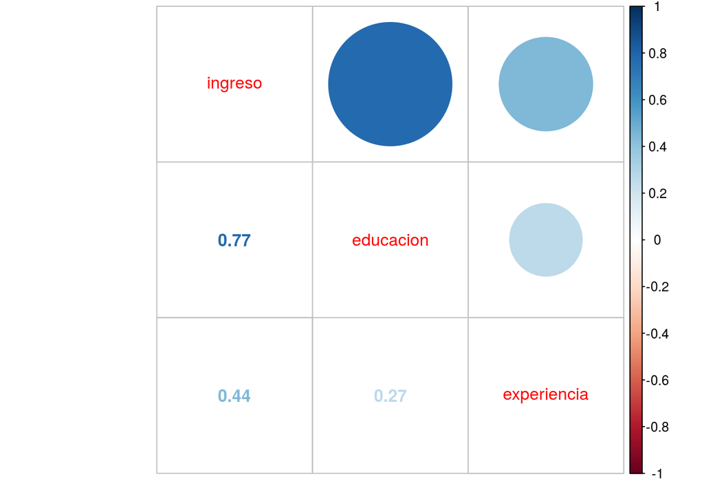

```r
corrplot.mixed(cormat)
```

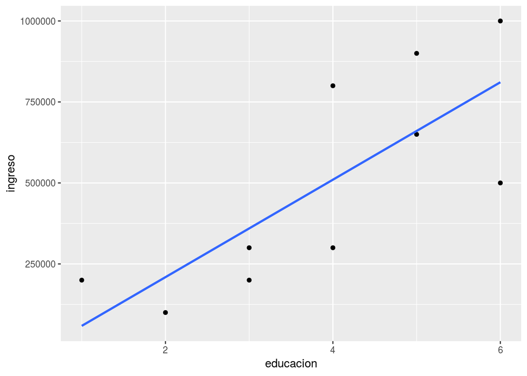

```r
ggplot(datos, aes(x=educacion, y=ingreso)) + geom_point() +
  geom_smooth(method=lm, se=FALSE)
```

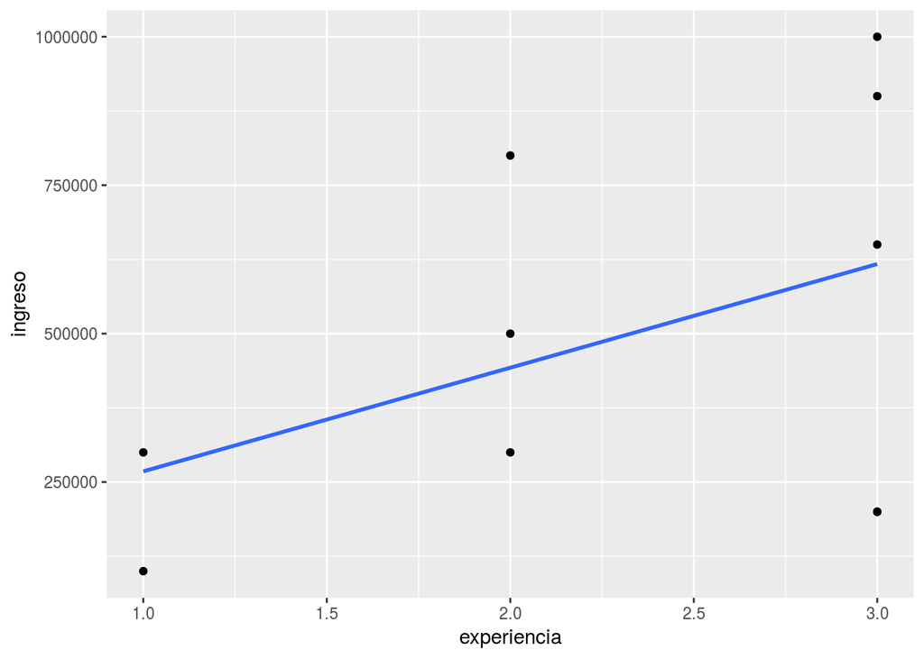

```r
ggplot(datos, aes(x=experiencia, y=ingreso)) + geom_point() +
  geom_smooth(method=lm, se=FALSE)
```

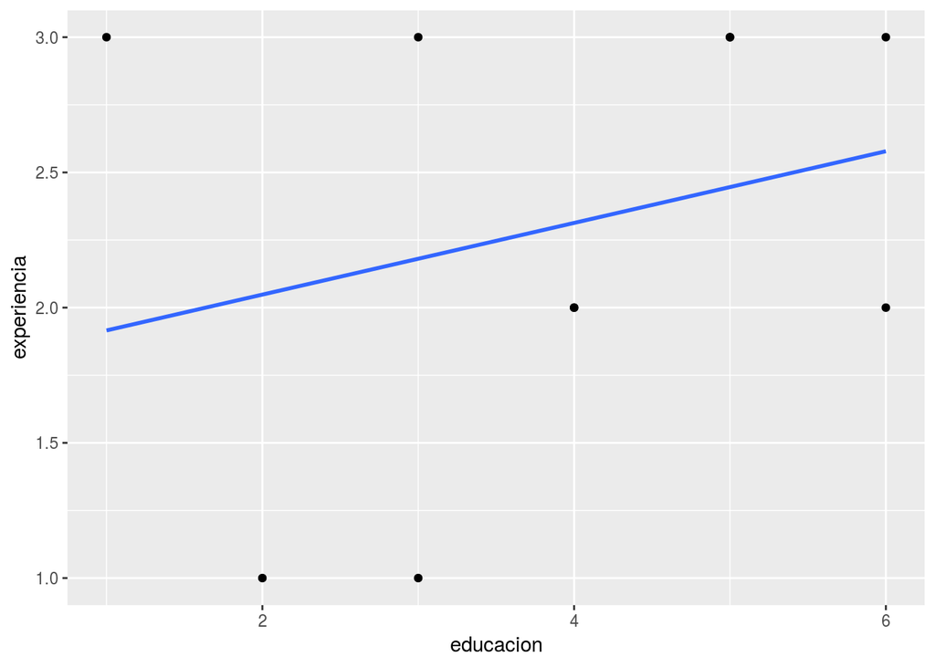

```r
ggplot(datos, aes(x=educacion, y=experiencia)) + geom_point() +
  geom_smooth(method=lm, se=FALSE)
```

## 2.3 Regresiones

```r
reg_y_x1=lm(ingreso ~ educacion, data=datos)
reg_y_x2=lm(ingreso ~ experiencia, data=datos)
reg_y_x1_x2=lm(ingreso ~ educacion + experiencia , data=datos)


screenreg(list(reg_y_x1,reg_y_x2,reg_y_x1_x2))
```

```
##
## =====================================================
##              Model 1        Model 2      Model 3
## -----------------------------------------------------
## (Intercept)   -91566.27       93442.62   -270638.30
##              (183509.80)    (302389.31)  (241882.27)
## educacion     150401.61 **                137092.20 *
##               (43618.69)                  (44602.35)
## experiencia                  174590.16    100425.53
##                             (124491.71)   (90114.05)
## -----------------------------------------------------
## R^2                0.60           0.20         0.66
## Adj. R^2           0.55           0.10         0.56
## Num. obs.         10             10           10
## RMSE          217656.84      307471.84    214438.31
## =====================================================
## *** p < 0.001, ** p < 0.01, * p < 0.05
```

## 2.4 Parciales

```r
reg_x1_x2=lm(educacion ~ experiencia , data=datos)

x1_fit_x2=fitted.values(reg_x1_x2)
resx1_2=residuals(reg_x1_x2)

datos=cbind(datos, x1_fit_x2,resx1_2)
datos
```

```
##    ID ingreso educacion experiencia x1_fit_x2    resx1_2
## 1   1  100000         2           1  3.196721 -1.1967213
## 2   2  200000         1           3  4.278689 -3.2786885
## 3   3  200000         3           3  4.278689 -1.2786885
## 4   4  300000         3           1  3.196721 -0.1967213
## 5   5  300000         4           2  3.737705  0.2622951
## 6   6  500000         6           2  3.737705  2.2622951
## 7   7  650000         5           3  4.278689  0.7213115
## 8   8  800000         4           2  3.737705  0.2622951
## 9   9  900000         5           3  4.278689  0.7213115
## 10 10 1000000         6           3  4.278689  1.7213115
```

```r
regy_resx1_2=lm(datos$ingreso ~ resx1_2)


screenreg(list(reg_y_x1,reg_y_x2,reg_y_x1_x2,regy_resx1_2), booktabs = TRUE, dcolumn = TRUE, doctype = FALSE, caption=" ")
```

```
##
## ====================================================================
##              Model 1        Model 2      Model 3       Model 4
## --------------------------------------------------------------------
## (Intercept)   -91566.27       93442.62   -270638.30    495000.00 ***
##              (183509.80)    (302389.31)  (241882.27)   (79673.16)
## educacion     150401.61 **                137092.20 *
##               (43618.69)                  (44602.35)
## experiencia                  174590.16    100425.53
##                             (124491.71)   (90114.05)
## resx1_2                                                137092.20 *
##                                                        (52404.36)
## --------------------------------------------------------------------
## R^2                0.60           0.20         0.66         0.46
## Adj. R^2           0.55           0.10         0.56         0.39
## Num. obs.         10             10           10           10
## RMSE          217656.84      307471.84    214438.31    251948.67
## ====================================================================
## *** p < 0.001, ** p < 0.01, * p < 0.05
```

¿Qué nos indica el coeficiente de regresión parcial? ¿Cómo se podría obtener el segundo coeficiente?

# 3 Ejercicio 2: Ejemplo de Darlington & Hayes

## 3.1 Datos

Los datos corresponden a la base de dato exercise que muestran Darlington y Hayes (2017) en el capitulo 3 de regresión multiple.

wtloss: variable continua de perdida de peso en gramos. food : variable continua de ingesta de comida medida en calorias exercise: promedio de horas de ejercicio a la semana.

## 3.2 Cargar bases de datos y librerias.

```r
#cargar base de datos
library(readr)
library(dplyr)
library(ggplot2)
library(car)
library(stargazer)
library(texreg)

# Leer datos

exercise <- read_table2("https://juancarloscastillo.github.io/metsoc-facsouchile/documents/practicas/3regmul/exercise.txt")


exercise %>% select(id, exercise, food, wtloss)->data #filtrar casos con variables a examinar
```

## 3.3 Sobre relaciones contraintuitivas

[output not shown]

Como se puede ver en los datos la correlación entre ejercicio y perdida de peso es de 0.86. Aquellas personas que se ejercitan más tienen una mayor reducción de peso. Por otro lado la correlación entre el consumo de de comida y la perdida de peso es de 0.047. Ignorando el hecho de que es una correlación bastante pequeña, se puede observar una relación positiva, que al menos exploratoriamente es contraintutiva. Es decir a mayor consumo de comida existiría una mayor reducción de peso.

Para entender este tipo de relaciones contraintuitivas una buena aproximación podría ser visualizar qué estaría ocurriendo con los datos. En el siguiente gráfico de dispersión se observa una relación levemente positiva entre la ingesta de comida y la perdida de peso.

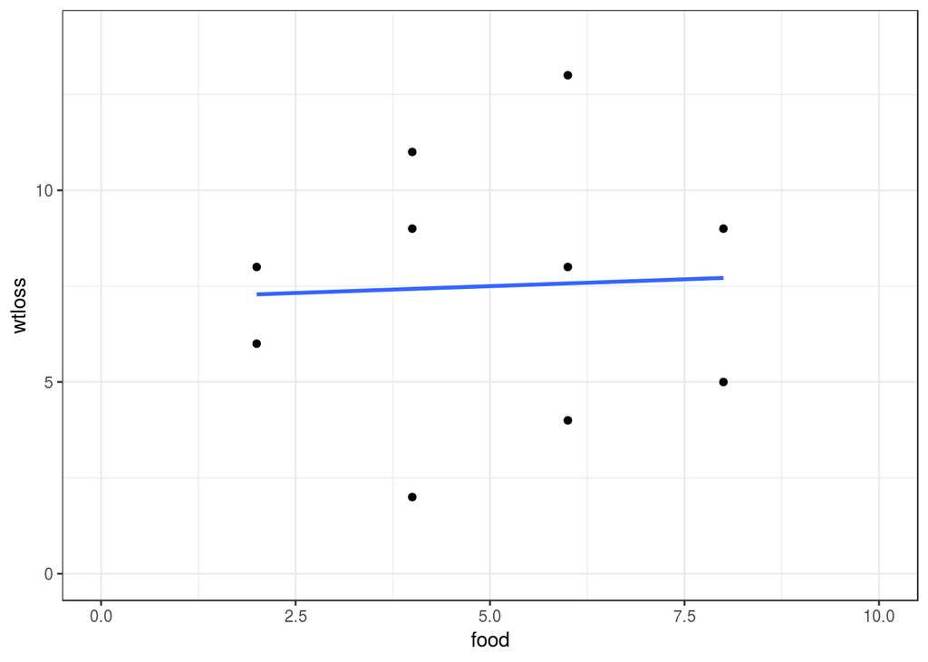

```r
#Relacion lineal entre comida y perdida de peso
ggplot(data, aes(x=food, y=wtloss)) +
  geom_point() +
  geom_smooth(method = "lm", se=F)+
  xlim(0, 10)+
  ylim(0, 14)+
  theme_bw()
```

Ahora bien, puede que entre la relación de ingesta de comida con la perdida de peso exista la presencia de otra variable que pueda estar confundiendo, y que no esta considerada.

En este caso, la variable que puede estar confundiendo refiere al ejercicio. En el siguiente gráfico se puede observar nítidamente esta relación.

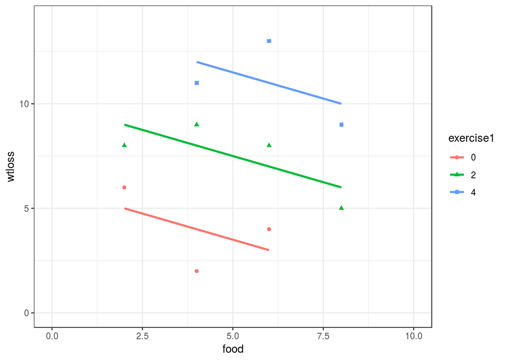

```r
data$exercise1<- as.factor(data$exercise) #recodificamos a factor para plotear

#Relacion lineal condicionada por cantidad de ejercicio.
ggplot(data, aes(x=food, y=wtloss,shape=exercise1,color=exercise1)) +
  geom_point() +
  geom_smooth(method = "lm", se=F)+
  xlim(0, 10)+
  ylim(0, 14)+
  theme_bw()
```

Al observar el anterior gráfico se puede constatar que si se toma en consideración las horas promedio semanal de ejercicio (en este caso, 0,2 y 4) la relación es negativa entre comida y perdida de peso. Es decir si estudiamos la relación entre comida y perdida de peso entre sujetos “comparables” en relación a su ejercicio, la relación se vuelve negativa.